# H06 daily metrics: day-level context and personal light exposure

Complementary preregistration-oriented participant-day evidence

Last modified:

August 13, 2026

## Scientific question

The signed hypothesis states: **“Day type (weekday/weekend; free/work day), daily exercise, and sleep variables predict daily light exposure metrics.”** This complementary analysis asks that question with one row per admissible metric-specific participant-day. It does not give days with more supported hours greater weight.

The completed hourly H06 analysis is the selected main H06 result. This participant-day analysis is complementary, preregistration-oriented evidence. The two analyses are related but have different outcomes and weighting; neither result substitutes for the other. The analysis-preparation and provenance companion documents the exact inputs, models, checks, and stored outputs used here.

**NoteAnswer in brief**

In the primary near-eye analysis, false-discovery-rate (FDR) adjustment, which limits the expected proportion of false discoveries within each prespecified 15-slot family, retained associations for **10 of 14 estimable metrics** with Free versus Work day, **6 of 14** with Active versus Sedentary status, and **12 of 14** per additional hour of previous-night sleep. Every retained association requires the model-check qualifications (model diagnostics), which assess fit, support, residual behavior, and sensitivity evidence, described below.

For outcomes fitted as $\log_{10}(Y + 0.1)$, $Y$ remains in its stated unit, such as lx for melEDI, h for continuous periods, or lx h for dose. The back-transformed ratios compare fitted geometric-mean-like values of $Y + 0.1$; they are not ratios of raw metric means.

- Free days had lower fitted mean melEDI, M10 mean, waking time above 250 lx melEDI, longest continuous period above 250 lx melEDI, and melEDI dose than Work days. M10 and L10 midpoints and first light above 250 lx melEDI were later, whereas last light above 250 lx melEDI was earlier.
- Active days had higher fitted mean melEDI, M10 mean, time above 1,000 and 250 lx melEDI, longest continuous period above 250 lx melEDI, and melEDI dose than Sedentary days.
- Longer previous-night sleep was associated with lower fitted light-level, bright-duration, longest-period, and dose metrics; more time below 1 lx melEDI during sleep; and later M10, L10, mean-light, and first-light timing.

Ten primary predictor-by-site interaction blocks, which allow an association to differ among sites, met their separate 15-slot FDR rule. For example, the interaction model estimated lower Free-day mean melEDI at every site, with pointwise 95% confidence intervals (95% CIs) excluding 1 at Dortmund (DE), Tübingen (DE), Madrid (ES), and Kumasi (GH). A pointwise interval assesses one site estimate at a time and is not a simultaneous band. The global interaction test establishes variation across sites, while the site intervals describe where the fitted site-specific contrasts are clearest.

In the exploratory mutually adjusted daily models, activity estimates were stable after adding day type and sleep. Three sleep estimates and four work/free estimates shifted by 1 to less than 2 standard errors. One work/free estimate, time below 1 lx melEDI during sleep, reversed direction and shifted by more than 3 standard errors. Mean melEDI nevertheless remained lower on Free days after adjustment, with a fitted ratio of 0.75 (95% CI 0.68 to 0.82; FDR q < 0.001).

The separate nonlinear generalized additive mixed model (GAMM) analysis of 30-minute bins allowed context associations to vary smoothly over clock time while accounting for repeated measurements. It found time-varying profiles for day type, activity, within-participant sleep, and between-participant sleep in its four-test exploratory FDR family. The selected main hourly H06 analysis does not give the same answer as the daily mean metric: hourly melEDI was higher on Free days, whereas the participant-day mean metric was lower. This difference is scientifically plausible because the analyses use different outcomes, weighting, and model structures.

The overall two-part L10 mean result remains non-estimable, and all three primary MDER 95% intervals included zero. The gap-timing-unaware analysis is reported only as a sensitivity.

## Data and analysis

### Outcomes, contexts, and sample roles

The 15 participant-day outcomes comprise mean melEDI; M10 and L10 mean melEDI; four threshold-duration measures; the longest continuous period above 250 lx melEDI; M10 and L10 midpoint; mean, first, and last timing above 250 lx melEDI; melEDI dose; and melanopic daylight efficacy ratio (MDER). “Period” describes the continuous-duration metric. Sleep-period light is interpreted as the bedside sleep environment, not verified ocular exposure.

The three primary contexts were:

- Free versus Work day;
- Active versus Sedentary daily activity status; and
- each additional hour of previous-night sleep duration, centered at 8 h.

Near-eye measurements are primary. All-available chest results are a complementary non-ocular comparison. Paired/common results compare the two placements after retaining the same participant-days in both placements. More generally, a common sample means that the compared models or placements use the same participant-days. The gap-timing-unaware dataset repeats the near-eye analysis as a separate metric-construction sensitivity.

Table 1: Analysis roles and exact fitted-sample ranges.

| Scenario | Analysis role | Participant-days | Participants | Sites |
| --- | --- | --- | --- | --- |
| Primary near eye, all available | Primary daily-metric estimates and six primary FDR families | 602–784 | 133–141 | 9 |
| Complementary chest, all available | Complementary placement estimates; no additional p-value family | 669–870 | 147–154 | 8 |
| Paired/common near eye | Near-eye estimates on common placement days | 444–614 | 104–112 | 8 |
| Paired/common chest | Chest estimates on the same common placement days | 444–614 | 104–112 | 8 |
| Gap-timing-unaware near eye, all available | Separate sensitivity estimates and six separate FDR families | 630–777 | 133–141 | 9 |

Ranges arise because every metric × predictor result uses its exact complete fitted frame. Exact denominators accompany every result below.

The nine study sites, in display order, are Borås (SE), Delft (NL), Dortmund (DE), Tübingen (DE), Munich (DE), Madrid (ES), Izmir (TR), San José (CR), Kumasi (GH). Primary near-eye results use all nine sites; the complementary chest and paired/common results use eight sites where both the placement and exact metric-specific frame are supported.

### Models, contrasts, and multiplicity

The non-timing outcomes use fixed study-site terms and a participant random intercept, which allows participants to have different baseline outcome levels. The primary models were fitted separately for each predictor, so their estimates are not mutually adjusted for the other two day-level contexts. The common-association and predictor-by-site interaction formulas are:

```
response ~ site + predictor + (1 | participant)
response ~ site * predictor + (1 | participant)
```

Four clock outcomes, M10 midpoint, L10 midpoint, first timing above 250 lx melEDI, and last timing above 250 lx melEDI, use the corresponding fixed-site linear models with participant-cluster HC3 uncertainty. All displayed intervals are **pointwise 95% confidence intervals (95% CIs)**; each assesses one estimate at a time, and none is simultaneous. A site-average estimate gives each included site equal weight, irrespective of its observed sample size.

Multiplicity comprises 12 separate FDR families: primary and gap-timing-unaware datasets × three predictors × association or predictor-by-site interaction. Every family retains all 15 named metric slots. L10 mean remains the non-estimable slot 3 with missing raw and adjusted p-values; MDER occupies slot 15 and has no association FDR support.

Table 2: Twelve fixed 15-slot FDR families.

| Predictor | Test | Named slots | Estimable slots | FDR-supported | Claim-eligible | Family valid |
| --- | --- | --- | --- | --- | --- | --- |
| Gap-timing-unaware |  |  |  |  |  |  |
| Work/free day | Association | 15 | 14 | 10 | 10 | Yes |
| Daily activity status | Association | 15 | 14 | 6 | 6 | Yes |
| Previous-night sleep duration | Association | 15 | 14 | 13 | 13 | Yes |
| Work/free day | Predictor-by-site interaction | 15 | 14 | 8 | 7 | Yes |
| Daily activity status | Predictor-by-site interaction | 15 | 14 | 3 | 3 | Yes |
| Previous-night sleep duration | Predictor-by-site interaction | 15 | 14 | 1 | 1 | Yes |
| Primary |  |  |  |  |  |  |
| Work/free day | Association | 15 | 14 | 10 | 10 | Yes |
| Daily activity status | Association | 15 | 14 | 6 | 6 | Yes |
| Previous-night sleep duration | Association | 15 | 14 | 12 | 12 | Yes |
| Work/free day | Predictor-by-site interaction | 15 | 14 | 8 | 7 | Yes |
| Daily activity status | Predictor-by-site interaction | 15 | 14 | 2 | 2 | Yes |
| Previous-night sleep duration | Predictor-by-site interaction | 15 | 14 | 1 | 1 | Yes |

FDR-supported counts are numerical q < 0.05 decisions. Claim-eligible counts additionally exclude MDER and retain all stated model-check limitations.

**NoteHow to read the estimates**

- A **site-average estimate** gives every included site equal weight. It is not weighted by the number of observations contributed by each site.
- A **predictor-by-site interaction** allows the association between a context and an outcome to differ among sites. A global interaction test does not by itself identify which site estimates differ.
- A **pointwise 95% CI** describes uncertainty for one displayed estimate. It is not a simultaneous interval across sites, metrics, or clock times.
- An **FDR adjustment** limits the expected proportion of false discoveries among the tests in its explicitly defined family.
- A **participant random intercept** allows participants to have different baseline outcome levels. A **common sample** retains the same participant-days across the compared models or placements.
- **Model checks** cover fit, support, residual behavior, and sensitivity evidence. A working first-order autoregressive correlation, **AR(1)**, allows adjacent residuals within a participant-day sequence to be correlated.

## Primary near-eye results

The first two figures show effect magnitude and pointwise uncertainty for the 13 estimable non-L10 metrics. For shifted-log outcomes, the response is $\log_{10}(Y + 0.1)$ and the displayed ratios compare fitted geometric-mean-like values of $Y + 0.1$ in the metric’s stated unit. They are not raw-metric ratios. Clock-time and absolute duration effects are differences in hours.

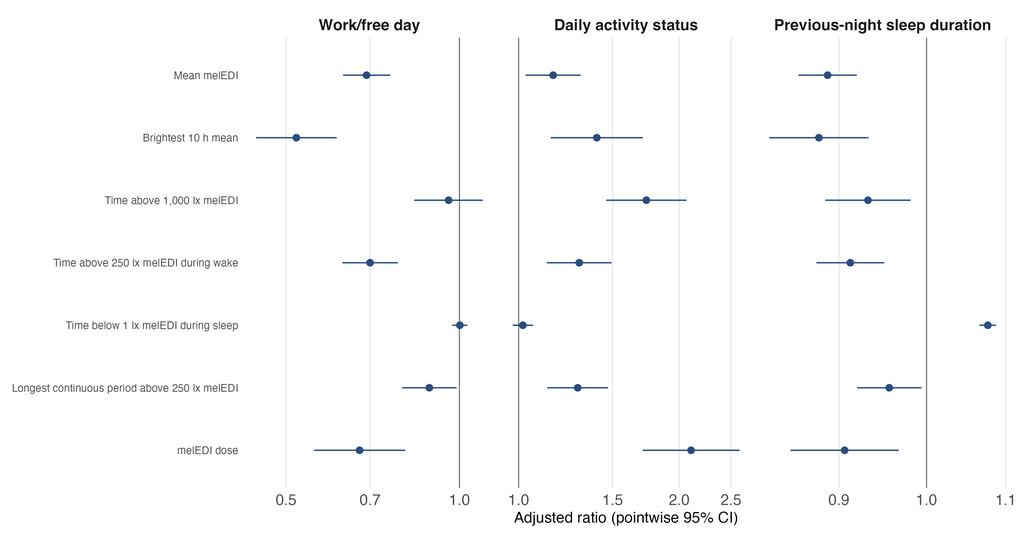

Figure 1: Primary near-eye multiplicative associations for seven daily metrics. Points and bars are estimates and pointwise 95% confidence intervals; the reference ratio is one.

Source data for the multiplicative figure

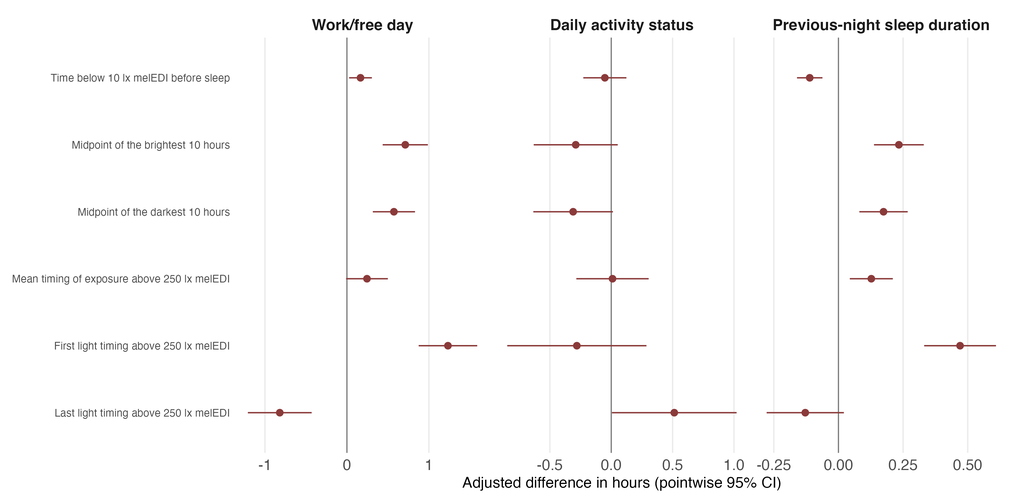

Figure 2: Primary near-eye absolute associations for six duration or timing metrics. Points and bars are differences in hours and pointwise 95% confidence intervals; the reference difference is zero.

Source data for the absolute-effect figure

The overview below shows the FDR decision for all 15 named slots in the primary and gap-timing-unaware families. Exact participant-days, participants, and sites for every symbol are included in its paired source CSV and in the result tables.

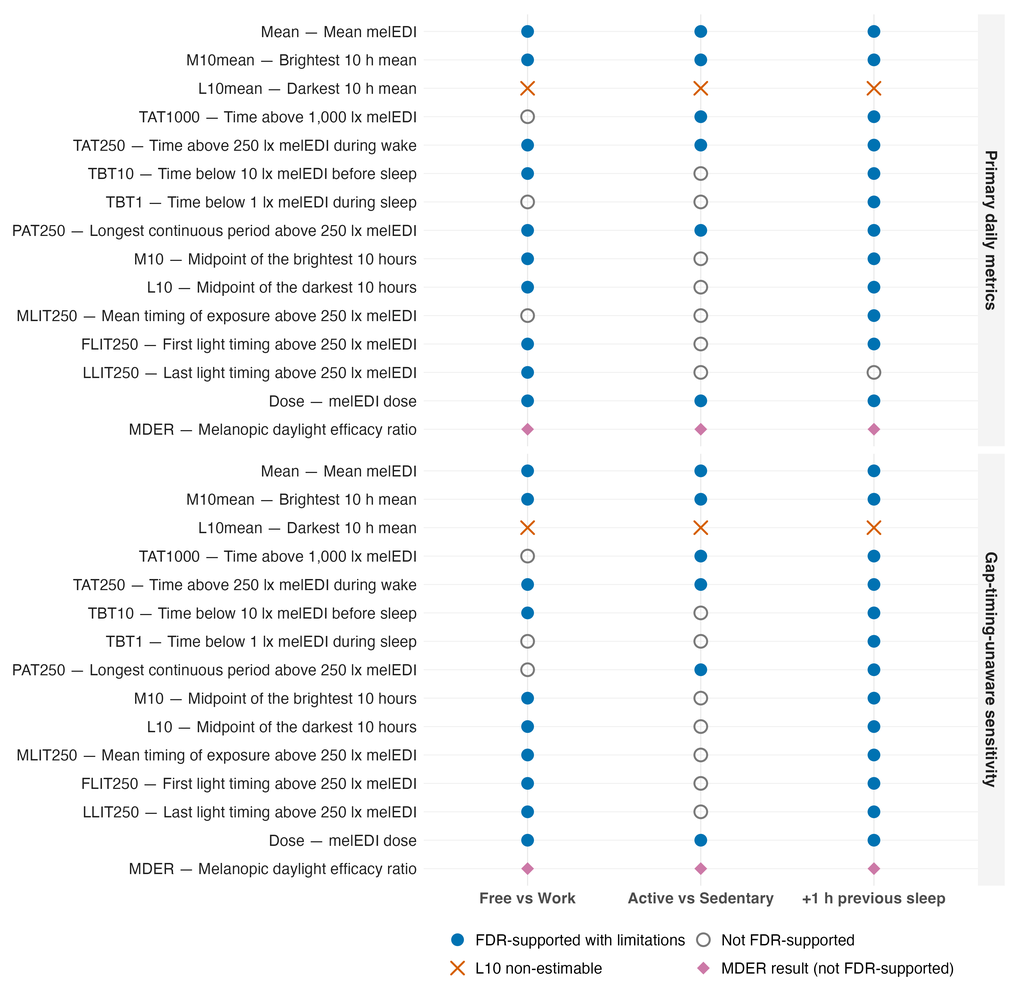

Figure 3: FDR decision overview for the primary and gap-timing-unaware daily-metric association families.

Source data for the FDR overview

The single table below keeps the complete **primary participant-day batch** together. Metrics appear once, while the three predictor-specific estimates occupy separate columns. Site-interaction results are deliberately kept in the following table rather than mixed into the association cells.

Table 3: Primary near-eye predictor-specific participant-day associations.

| Metric | Free / Work | Active / Sedentary | +1 h previous sleep |
| --- | --- | --- | --- |
| Light level |  |  |  |
| Mean melEDI | 0.69× (0.63 to 0.76) **q = <0.001**; 784 days / 141 participants | 1.16× (1.03 to 1.31) **q = 0.035**; 734 days / 137 participants | 0.89× (0.86 to 0.92) **q = <0.001**; 784 days / 141 participants |
| Brightest 10 h mean | 0.52× (0.44 to 0.61) **q = <0.001**; 784 days / 141 participants | 1.40× (1.15 to 1.71) **q = 0.003**; 734 days / 137 participants | 0.88× (0.83 to 0.93) **q = <0.001**; 784 days / 141 participants |
| Darkest 10 h mean | Not estimable; q = — | Not estimable; q = — | Not estimable; q = — |
| Duration and continuous periods |  |  |  |
| Time above 1,000 lx melEDI | 0.96× (0.83 to 1.10) q = 0.669; 784 days / 141 participants | 1.74× (1.46 to 2.06) **q = <0.001**; 734 days / 137 participants | 0.93× (0.89 to 0.98) **q = 0.010**; 784 days / 141 participants |
| Time above 250 lx melEDI during wake | 0.70× (0.63 to 0.78) **q = <0.001**; 729 days / 141 participants | 1.30× (1.13 to 1.49) **q = <0.001**; 675 days / 136 participants | 0.91× (0.88 to 0.95) **q = <0.001**; 729 days / 141 participants |
| Time below 10 lx melEDI before sleep | +0.17 h (+0.03 to +0.30) **q = 0.030**; 648 days / 139 participants | -0.05 h (-0.23 to +0.12) q = 0.677; 602 days / 134 participants | -0.11 h (-0.16 to -0.06) **q = <0.001**; 648 days / 139 participants |
| Time below 1 lx melEDI during sleep | 1.00× (0.97 to 1.03) q = 0.986; 770 days / 141 participants | 1.02× (0.97 to 1.06) q = 0.520; 713 days / 136 participants | 1.08× (1.07 to 1.09) **q = <0.001**; 770 days / 141 participants |
| Longest continuous period above 250 lx melEDI | 0.89× (0.80 to 0.99) **q = 0.044**; 784 days / 141 participants | 1.29× (1.13 to 1.47) **q = <0.001**; 734 days / 137 participants | 0.96× (0.92 to 0.99) **q = 0.028**; 784 days / 141 participants |
| Timing |  |  |  |
| Midpoint of the brightest 10 hours | +0.71 h (+0.44 to +0.99) **q = <0.001**; 784 days / 141 participants | -0.29 h (-0.63 to +0.05) q = 0.162; 734 days / 137 participants | +0.23 h (+0.14 to +0.33) **q = <0.001**; 784 days / 141 participants |
| Midpoint of the darkest 10 hours | +0.57 h (+0.32 to +0.83) **q = <0.001**; 784 days / 141 participants | -0.31 h (-0.63 to +0.01) q = 0.113; 734 days / 137 participants | +0.17 h (+0.08 to +0.27) **q = <0.001**; 784 days / 141 participants |
| Mean timing of exposure above 250 lx melEDI | +0.24 h (-0.01 to +0.50) q = 0.081; 715 days / 141 participants | +0.01 h (-0.28 to +0.30) q = 1.000; 676 days / 137 participants | +0.13 h (+0.04 to +0.21) **q = 0.004**; 715 days / 141 participants |
| First light timing above 250 lx melEDI | +1.23 h (+0.87 to +1.59) **q = <0.001**; 701 days / 140 participants | -0.28 h (-0.85 to +0.29) q = 0.450; 658 days / 136 participants | +0.47 h (+0.33 to +0.61) **q = <0.001**; 701 days / 140 participants |
| Last light timing above 250 lx melEDI | -0.82 h (-1.21 to -0.43) **q = <0.001**; 661 days / 141 participants | +0.51 h (+0.01 to +1.02) q = 0.102; 626 days / 137 participants | -0.13 h (-0.28 to +0.02) q = 0.106; 661 days / 141 participants |
| Exposure history |  |  |  |
| melEDI dose | 0.67× (0.56 to 0.81) **q = <0.001**; 729 days / 141 participants | 2.11× (1.71 to 2.59) **q = <0.001**; 686 days / 137 participants | 0.91× (0.85 to 0.97) **q = 0.004**; 729 days / 141 participants |
| Spectrum |  |  |  |
| Melanopic daylight efficacy ratio | -0.001 (-0.013 to +0.011) q = 0.958; 679 days / 136 participants | +0.008 (-0.007 to +0.024) q = 0.413; 645 days / 133 participants | +0.002 (-0.003 to +0.006) q = 0.517; 679 days / 136 participants |

Batch: primary near-eye predictor-specific participant-day models. Each cell gives the estimate (pointwise 95% CI, not a simultaneous interval), its 15-slot FDR q-value, and the exact fitted participant-days and participants. Raw p-values and complete model fields remain in the linked source CSV. Bold q-values meet the FDR and claim-eligibility rule. All primary frames use nine sites.

### Supported predictor-by-site interactions

Ten global predictor-by-site interaction blocks met the separate 15-slot FDR rule. A retained global interaction indicates that the predictor association varies across sites. It does not identify a pair of sites that differ. The table first gives the **site-average comparison-versus-reference contrast from the complete interaction model**, with every site weighted equally. For these ratio-scale outcomes, it is the geometric mean of the nine full site-specific ratios. The site entries then show adjustment factors relative to that site-average contrast:

An adjustment factor below 1 means that the site’s fitted ratio is lower than the site-average ratio; a factor above 1 means it is higher. Multiplying the site-average ratio by the adjustment factor recovers the site’s full fitted ratio. The pointwise intervals localize the fitted pattern, but they are not separately multiplicity adjusted and are not pairwise site comparisons.

Table 4: Site-average contrasts and site adjustment factors for primary interaction blocks retained by the global FDR rule.

| Metric | Global interaction FDR q | Site-average comparison / reference | Site adjustment below site average; pointwise 95% CI excludes 1 | Site adjustment above site average; pointwise 95% CI excludes 1 | Site adjustment compatible with site average; pointwise 95% CI includes 1 |
| --- | --- | --- | --- | --- | --- |
| Work/free day |  |  |  |  |  |
| Mean melEDI | **q = 0.002** | **0.70×** (0.63 to 0.78) | ● Madrid (ES): ×0.71 (0.56 to 0.90); ● Kumasi (GH): ×0.57 (0.43 to 0.76) | ● Delft (NL): ×1.36 (1.01 to 1.83) | ● Borås (SE): ×1.12 (0.85 to 1.48); ● Dortmund (DE): ×1.01 (0.79 to 1.30); ● Tübingen (DE): ×1.09 (0.88 to 1.34); ● Munich (DE): ×1.24 (0.91 to 1.69); ● Izmir (TR): ×1.14 (0.89 to 1.48); ● San José (C… |
| Brightest 10 h mean | **q = <0.001** | **0.54×** (0.45 to 0.65) | ● Madrid (ES): ×0.52 (0.34 to 0.77); ● Kumasi (GH): ×0.35 (0.22 to 0.57) | ● Delft (NL): ×1.84 (1.11 to 3.04); ● Dortmund (DE): ×1.73 (1.12 to 2.65) | ● Borås (SE): ×0.98 (0.61 to 1.58); ● Tübingen (DE): ×1.01 (0.71 to 1.45); ● Munich (DE): ×1.51 (0.90 to 2.55); ● Izmir (TR): ×0.93 (0.60 to 1.44); ● San José (CR): ×1.23 (0.54 to 2.79) |
| Time above 1,000 lx melEDI | **q = 0.015** | **0.93×** (0.79 to 1.09) | ● Izmir (TR): ×0.56 (0.36 to 0.87); ● Kumasi (GH): ×0.57 (0.37 to 0.87) | ● Dortmund (DE): ×1.53 (1.09 to 2.14) | ● Borås (SE): ×1.18 (0.82 to 1.68); ● Delft (NL): ×1.07 (0.72 to 1.59); ● Tübingen (DE): ×0.93 (0.67 to 1.28); ● Munich (DE): ×1.21 (0.77 to 1.88); ● Madrid (ES): ×1.27 (0.86 to 1.86); ● San José (CR)… |
| Time above 250 lx melEDI during wake | **q = 0.013** | **0.70×** (0.61 to 0.79) | ● Madrid (ES): ×0.62 (0.46 to 0.83) | ● Dortmund (DE): ×1.49 (1.12 to 1.99) | ● Borås (SE): ×1.05 (0.78 to 1.41); ● Delft (NL): ×1.26 (0.90 to 1.76); ● Tübingen (DE): ×1.06 (0.83 to 1.37); ● Munich (DE): ×0.97 (0.68 to 1.38); ● Izmir (TR): ×1.02 (0.74 to 1.41); ● San José (CR):… |
| Time below 1 lx melEDI during sleep | **q = 0.011** | **0.99×** (0.96 to 1.03) | None | ● Dortmund (DE): ×1.11 (1.03 to 1.21); ● Madrid (ES): ×1.11 (1.03 to 1.20) | ● Borås (SE): ×0.98 (0.90 to 1.07); ● Delft (NL): ×0.94 (0.86 to 1.03); ● Tübingen (DE): ×0.94 (0.88 to 1.01); ● Munich (DE): ×0.94 (0.85 to 1.04); ● Izmir (TR): ×0.96 (0.88 to 1.04); ● San José (CR):… |
| Longest continuous period above 250 lx melEDI | **q = 0.024** | **0.89×** (0.79 to 1.00) | ● Kumasi (GH): ×0.69 (0.50 to 0.96) | ● Dortmund (DE): ×1.69 (1.26 to 2.27) | ● Borås (SE): ×1.01 (0.73 to 1.40); ● Delft (NL): ×1.16 (0.82 to 1.63); ● Tübingen (DE): ×0.94 (0.74 to 1.20); ● Munich (DE): ×1.10 (0.77 to 1.57); ● Madrid (ES): ×0.84 (0.64 to 1.11); ● Izmir (TR): ×… |
| melEDI dose | **q = <0.001** | **0.69×** (0.56 to 0.84) | ● Kumasi (GH): ×0.26 (0.15 to 0.44) | ● Dortmund (DE): ×2.28 (1.40 to 3.71) | ● Borås (SE): ×1.53 (0.89 to 2.65); ● Delft (NL): ×1.46 (0.83 to 2.58); ● Tübingen (DE): ×0.92 (0.61 to 1.38); ● Munich (DE): ×0.86 (0.48 to 1.54); ● Madrid (ES): ×1.04 (0.67 to 1.63); ● Izmir (TR): ×… |
| Daily activity status |  |  |  |  |  |
| Mean melEDI | **q = 0.014** | **1.22×** (1.08 to 1.39) | ● Dortmund (DE): ×0.68 (0.51 to 0.93); ● Izmir (TR): ×0.70 (0.52 to 0.95) | ● Kumasi (GH): ×1.85 (1.25 to 2.73) | ● Borås (SE): ×1.15 (0.83 to 1.58); ● Delft (NL): ×1.47 (0.96 to 2.26); ● Tübingen (DE): ×1.04 (0.79 to 1.38); ● Munich (DE): ×0.95 (0.65 to 1.39); ● Madrid (ES): ×0.78 (0.57 to 1.06); ● San José (CR)… |
| melEDI dose | **q = 0.011** | **2.25×** (1.80 to 2.81) | None | ● Kumasi (GH): ×5.28 (2.60 to 10.71) | ● Borås (SE): ×1.01 (0.57 to 1.79); ● Delft (NL): ×1.18 (0.57 to 2.47); ● Dortmund (DE): ×0.69 (0.40 to 1.19); ● Tübingen (DE): ×1.14 (0.70 to 1.86); ● Munich (DE): ×0.81 (0.42 to 1.54); ● Madrid (ES)… |
| Previous-night sleep duration |  |  |  |  |  |
| Brightest 10 h mean | **q = 0.045** | **0.89×** (0.83 to 0.95) | ● Madrid (ES): ×0.80 (0.69 to 0.92); ● Kumasi (GH): ×0.80 (0.67 to 0.95) | None | ● Borås (SE): ×0.92 (0.74 to 1.15); ● Delft (NL): ×1.23 (0.98 to 1.55); ● Dortmund (DE): ×1.12 (0.93 to 1.35); ● Tübingen (DE): ×1.11 (0.97 to 1.28); ● Munich (DE): ×0.98 (0.80 to 1.19); ● Izmir (TR):… |

Batch: primary near-eye predictor-specific interaction models. The site-average column gives the equal-weight comparison/reference ratio from the complete interaction model: Free/Work, Active/Sedentary, or per additional hour of previous-night sleep. Each site adjustment is its full site-specific ratio divided by that site-average ratio; multiply the two to recover the full site-specific ratio. Site intervals are unadjusted pointwise 95% CIs and do not test one site against another. The bold q-value is the global interaction-block test. Filled dots use consistent study-site colors and do not encode significance.

For the author’s mean-melEDI example, the site-average Free/Work ratio from the interaction model was 0.70 (95% CI 0.63 to 0.78), with every site weighted equally. Delft (NL) had a pointwise higher site adjustment, 1.36 (1.01 to 1.83), meaning a weaker Free-day reduction than the site-average pattern. Madrid (ES), 0.71 (0.56 to 0.90), and Kumasi (GH), 0.57 (0.43 to 0.76), had pointwise lower adjustments, meaning stronger reductions. The remaining six adjustment intervals included 1. For example, the full fitted Delft (NL) ratio is 0.70 × 1.36 = 0.95, apart from rounding.

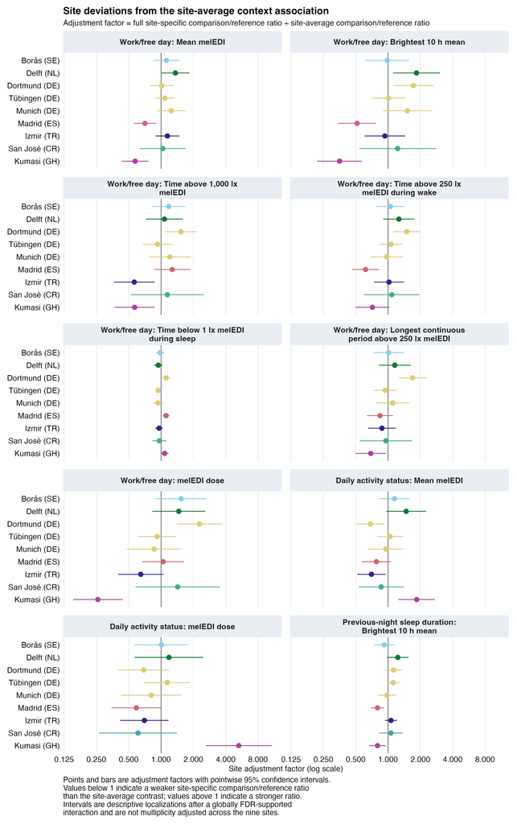

Figure 4: Site deviations from the site-average context association.

Source data for the site-deviation figure

Complete site-specific interaction estimates

The L10 occurrence component had complete or quasi-complete separation, so the overall two-part association and predictor-by-site interaction tests were not estimable. Positive-only and regularized component model checks do not replace that overall result. MDER is the arithmetic mean of viable positive finite one-minute melEDI/illuminance ratios; its primary estimates were −0.001 for Free versus Work day (95% CI −0.013 to 0.011), 0.008 for Active versus Sedentary (−0.007 to 0.024), and 0.002 per additional hour of sleep (−0.003 to 0.006).

## Complementary placement evidence

Chest and paired/common estimates use the same metric-specific effect scale as the primary result but are estimation-only. They are not pooled with near-eye measurements, and no extra significance screen is applied.

**Free versus Work day**

Table 5: Near-eye, chest, and paired/common estimates for Free versus Work day.

| Metric | Primary near eye, all available | Complementary chest, all available | Paired/common near eye | Paired/common chest |
| --- | --- | --- | --- | --- |
| Light level |  |  |  |  |
| Mean melEDI | 0.69× (0.63 to 0.76); n = 784 days / 141 participants / 9 sites | 0.59× (0.54 to 0.66); n = 870 days / 154 participants / 8 sites | 0.67× (0.60 to 0.75); n = 614 days / 112 participants / 8 sites | 0.61× (0.54 to 0.69); n = 614 days / 112 participants / 8 sites |
| Brightest 10 h mean | 0.52× (0.44 to 0.61); n = 784 days / 141 participants / 9 sites | 0.46× (0.39 to 0.55); n = 870 days / 154 participants / 8 sites | 0.51× (0.42 to 0.61); n = 614 days / 112 participants / 8 sites | 0.45× (0.37 to 0.56); n = 614 days / 112 participants / 8 sites |
| Darkest 10 h mean | Not estimable; n = 784 days / 141 participants / 9 sites | Not estimable; n = 870 days / 154 participants / 8 sites | Not estimable; n = 614 days / 112 participants / 8 sites | Not estimable; n = 614 days / 112 participants / 8 sites |
| Duration and continuous periods |  |  |  |  |
| Time above 1,000 lx melEDI | 0.96× (0.83 to 1.10); n = 784 days / 141 participants / 9 sites | 0.96× (0.85 to 1.09); n = 870 days / 154 participants / 8 sites | 0.97× (0.83 to 1.14); n = 614 days / 112 participants / 8 sites | 0.95× (0.82 to 1.10); n = 614 days / 112 participants / 8 sites |
| Time above 250 lx melEDI during wake | 0.70× (0.63 to 0.78); n = 729 days / 141 participants / 9 sites | 0.73× (0.66 to 0.81); n = 811 days / 154 participants / 8 sites | 0.70× (0.62 to 0.79); n = 571 days / 112 participants / 8 sites | 0.70× (0.62 to 0.79); n = 571 days / 112 participants / 8 sites |
| Time below 10 lx melEDI before sleep | +0.17 h (+0.03 to +0.30); n = 648 days / 139 participants / 9 sites | +0.22 h (+0.09 to +0.36); n = 737 days / 153 participants / 8 sites | +0.14 h (-0.01 to +0.30); n = 499 days / 110 participants / 8 sites | +0.14 h (-0.02 to +0.30); n = 499 days / 110 participants / 8 sites |
| Time below 1 lx melEDI during sleep | 1.00× (0.97 to 1.03); n = 770 days / 141 participants / 9 sites | 1.05× (1.02 to 1.08); n = 854 days / 154 participants / 8 sites | 1.02× (0.98 to 1.05); n = 601 days / 112 participants / 8 sites | 1.03× (0.99 to 1.07); n = 601 days / 112 participants / 8 sites |
| Longest continuous period above 250 lx melEDI | 0.89× (0.80 to 0.99); n = 784 days / 141 participants / 9 sites | 0.90× (0.81 to 1.00); n = 870 days / 154 participants / 8 sites | 0.91× (0.80 to 1.03); n = 614 days / 112 participants / 8 sites | 0.90× (0.79 to 1.02); n = 614 days / 112 participants / 8 sites |
| Timing |  |  |  |  |
| Midpoint of the brightest 10 hours | +0.71 h (+0.44 to +0.99); n = 784 days / 141 participants / 9 sites | +0.63 h (+0.35 to +0.91); n = 870 days / 154 participants / 8 sites | +0.77 h (+0.44 to +1.10); n = 614 days / 112 participants / 8 sites | +0.65 h (+0.32 to +0.98); n = 614 days / 112 participants / 8 sites |
| Midpoint of the darkest 10 hours | +0.57 h (+0.32 to +0.83); n = 784 days / 141 participants / 9 sites | +0.62 h (+0.38 to +0.86); n = 870 days / 154 participants / 8 sites | +0.55 h (+0.24 to +0.86); n = 614 days / 112 participants / 8 sites | +0.59 h (+0.30 to +0.87); n = 614 days / 112 participants / 8 sites |
| Mean timing of exposure above 250 lx melEDI | +0.24 h (-0.01 to +0.50); n = 715 days / 141 participants / 9 sites | +0.33 h (+0.09 to +0.57); n = 805 days / 154 participants / 8 sites | +0.26 h (-0.04 to +0.55); n = 550 days / 112 participants / 8 sites | +0.15 h (-0.13 to +0.44); n = 550 days / 112 participants / 8 sites |
| First light timing above 250 lx melEDI | +1.23 h (+0.87 to +1.59); n = 701 days / 140 participants / 9 sites | +1.49 h (+1.13 to +1.86); n = 776 days / 154 participants / 8 sites | +1.27 h (+0.86 to +1.69); n = 541 days / 112 participants / 8 sites | +1.56 h (+1.12 to +1.99); n = 541 days / 112 participants / 8 sites |
| Last light timing above 250 lx melEDI | -0.82 h (-1.21 to -0.43); n = 661 days / 141 participants / 9 sites | -0.89 h (-1.21 to -0.57); n = 761 days / 154 participants / 8 sites | -0.93 h (-1.35 to -0.50); n = 502 days / 112 participants / 8 sites | -1.01 h (-1.40 to -0.62); n = 502 days / 112 participants / 8 sites |
| Exposure history |  |  |  |  |
| melEDI dose | 0.67× (0.56 to 0.81); n = 729 days / 141 participants / 9 sites | 0.70× (0.58 to 0.85); n = 820 days / 154 participants / 8 sites | 0.68× (0.55 to 0.85); n = 569 days / 112 participants / 8 sites | 0.63× (0.50 to 0.80); n = 569 days / 112 participants / 8 sites |
| Spectrum |  |  |  |  |
| Melanopic daylight efficacy ratio | -0.001 (-0.013 to +0.011); n = 679 days / 136 participants / 9 sites | -0.007 (-0.021 to +0.006); n = 709 days / 151 participants / 8 sites | +0.001 (-0.016 to +0.017); n = 469 days / 106 participants / 8 sites | +0.001 (-0.013 to +0.015); n = 469 days / 106 participants / 8 sites |

Each cell is the estimate (pointwise 95% CI, not a simultaneous interval) followed by its exact participant-days, participants, and sites. Chest and common-day placement results are estimation-only complements; no additional p-value family was created.

**Activity status**

Table 6: Near-eye, chest, and paired/common estimates for Active versus Sedentary status.

| Metric | Primary near eye, all available | Complementary chest, all available | Paired/common near eye | Paired/common chest |
| --- | --- | --- | --- | --- |
| Light level |  |  |  |  |
| Mean melEDI | 1.16× (1.03 to 1.31); n = 734 days / 137 participants / 9 sites | 1.15× (1.01 to 1.30); n = 810 days / 149 participants / 8 sites | 1.14× (0.99 to 1.32); n = 571 days / 109 participants / 8 sites | 1.12× (0.95 to 1.31); n = 571 days / 109 participants / 8 sites |
| Brightest 10 h mean | 1.40× (1.15 to 1.71); n = 734 days / 137 participants / 9 sites | 1.43× (1.17 to 1.76); n = 810 days / 149 participants / 8 sites | 1.35× (1.07 to 1.71); n = 571 days / 109 participants / 8 sites | 1.38× (1.06 to 1.78); n = 571 days / 109 participants / 8 sites |
| Darkest 10 h mean | Not estimable; n = 734 days / 137 participants / 9 sites | Not estimable; n = 810 days / 149 participants / 8 sites | Not estimable; n = 571 days / 109 participants / 8 sites | Not estimable; n = 571 days / 109 participants / 8 sites |
| Duration and continuous periods |  |  |  |  |
| Time above 1,000 lx melEDI | 1.74× (1.46 to 2.06); n = 734 days / 137 participants / 9 sites | 1.58× (1.37 to 1.84); n = 810 days / 149 participants / 8 sites | 1.75× (1.45 to 2.12); n = 571 days / 109 participants / 8 sites | 1.58× (1.31 to 1.90); n = 571 days / 109 participants / 8 sites |
| Time above 250 lx melEDI during wake | 1.30× (1.13 to 1.49); n = 675 days / 136 participants / 9 sites | 1.29× (1.14 to 1.46); n = 741 days / 148 participants / 8 sites | 1.20× (1.03 to 1.39); n = 521 days / 108 participants / 8 sites | 1.22× (1.05 to 1.41); n = 521 days / 108 participants / 8 sites |
| Time below 10 lx melEDI before sleep | -0.05 h (-0.23 to +0.12); n = 602 days / 134 participants / 9 sites | +0.01 h (-0.14 to +0.17); n = 676 days / 147 participants / 8 sites | +0.03 h (-0.16 to +0.23); n = 458 days / 106 participants / 8 sites | +0.03 h (-0.17 to +0.22); n = 458 days / 106 participants / 8 sites |
| Time below 1 lx melEDI during sleep | 1.02× (0.97 to 1.06); n = 713 days / 136 participants / 9 sites | 1.00× (0.97 to 1.04); n = 783 days / 148 participants / 8 sites | 1.01× (0.96 to 1.06); n = 550 days / 108 participants / 8 sites | 1.02× (0.97 to 1.08); n = 550 days / 108 participants / 8 sites |
| Longest continuous period above 250 lx melEDI | 1.29× (1.13 to 1.47); n = 734 days / 137 participants / 9 sites | 1.26× (1.12 to 1.41); n = 810 days / 149 participants / 8 sites | 1.25× (1.08 to 1.45); n = 571 days / 109 participants / 8 sites | 1.20× (1.03 to 1.39); n = 571 days / 109 participants / 8 sites |
| Timing |  |  |  |  |
| Midpoint of the brightest 10 hours | -0.29 h (-0.63 to +0.05); n = 734 days / 137 participants / 9 sites | -0.01 h (-0.36 to +0.35); n = 810 days / 149 participants / 8 sites | -0.24 h (-0.64 to +0.16); n = 571 days / 109 participants / 8 sites | -0.05 h (-0.49 to +0.39); n = 571 days / 109 participants / 8 sites |
| Midpoint of the darkest 10 hours | -0.31 h (-0.63 to +0.01); n = 734 days / 137 participants / 9 sites | -0.14 h (-0.46 to +0.18); n = 810 days / 149 participants / 8 sites | -0.22 h (-0.59 to +0.16); n = 571 days / 109 participants / 8 sites | -0.01 h (-0.43 to +0.40); n = 571 days / 109 participants / 8 sites |
| Mean timing of exposure above 250 lx melEDI | +0.01 h (-0.28 to +0.30); n = 676 days / 137 participants / 9 sites | +0.17 h (-0.10 to +0.44); n = 753 days / 149 participants / 8 sites | -0.05 h (-0.38 to +0.28); n = 516 days / 109 participants / 8 sites | +0.09 h (-0.25 to +0.42); n = 516 days / 109 participants / 8 sites |
| First light timing above 250 lx melEDI | -0.28 h (-0.85 to +0.29); n = 658 days / 136 participants / 9 sites | -0.30 h (-0.76 to +0.16); n = 727 days / 149 participants / 8 sites | -0.29 h (-0.90 to +0.31); n = 505 days / 109 participants / 8 sites | -0.28 h (-0.82 to +0.26); n = 505 days / 109 participants / 8 sites |
| Last light timing above 250 lx melEDI | +0.51 h (+0.01 to +1.02); n = 626 days / 137 participants / 9 sites | +0.48 h (+0.10 to +0.86); n = 715 days / 149 participants / 8 sites | +0.29 h (-0.22 to +0.81); n = 473 days / 109 participants / 8 sites | +0.32 h (-0.16 to +0.80); n = 473 days / 109 participants / 8 sites |
| Exposure history |  |  |  |  |
| melEDI dose | 2.11× (1.71 to 2.59); n = 686 days / 137 participants / 9 sites | 1.96× (1.60 to 2.41); n = 764 days / 149 participants / 8 sites | 2.07× (1.62 to 2.63); n = 532 days / 109 participants / 8 sites | 2.00× (1.53 to 2.60); n = 532 days / 109 participants / 8 sites |
| Spectrum |  |  |  |  |
| Melanopic daylight efficacy ratio | +0.008 (-0.007 to +0.024); n = 645 days / 133 participants / 9 sites | +0.006 (-0.010 to +0.023); n = 669 days / 147 participants / 8 sites | +0.009 (-0.010 to +0.029); n = 444 days / 104 participants / 8 sites | +0.004 (-0.013 to +0.021); n = 444 days / 104 participants / 8 sites |

Each cell is the estimate (pointwise 95% CI, not a simultaneous interval) followed by its exact participant-days, participants, and sites. Chest and common-day placement results are estimation-only complements; no additional p-value family was created.

**Previous-night sleep duration**

Table 7: Near-eye, chest, and paired/common estimates per additional hour of previous-night sleep.

| Metric | Primary near eye, all available | Complementary chest, all available | Paired/common near eye | Paired/common chest |
| --- | --- | --- | --- | --- |
| Light level |  |  |  |  |
| Mean melEDI | 0.89× (0.86 to 0.92); n = 784 days / 141 participants / 9 sites | 0.86× (0.82 to 0.89); n = 870 days / 154 participants / 8 sites | 0.87× (0.83 to 0.91); n = 614 days / 112 participants / 8 sites | 0.86× (0.82 to 0.90); n = 614 days / 112 participants / 8 sites |
| Brightest 10 h mean | 0.88× (0.83 to 0.93); n = 784 days / 141 participants / 9 sites | 0.83× (0.78 to 0.88); n = 870 days / 154 participants / 8 sites | 0.85× (0.79 to 0.91); n = 614 days / 112 participants / 8 sites | 0.83× (0.77 to 0.89); n = 614 days / 112 participants / 8 sites |
| Darkest 10 h mean | Not estimable; n = 784 days / 141 participants / 9 sites | Not estimable; n = 870 days / 154 participants / 8 sites | Not estimable; n = 614 days / 112 participants / 8 sites | Not estimable; n = 614 days / 112 participants / 8 sites |
| Duration and continuous periods |  |  |  |  |
| Time above 1,000 lx melEDI | 0.93× (0.89 to 0.98); n = 784 days / 141 participants / 9 sites | 0.92× (0.88 to 0.96); n = 870 days / 154 participants / 8 sites | 0.91× (0.86 to 0.96); n = 614 days / 112 participants / 8 sites | 0.91× (0.86 to 0.96); n = 614 days / 112 participants / 8 sites |
| Time above 250 lx melEDI during wake | 0.91× (0.88 to 0.95); n = 729 days / 141 participants / 9 sites | 0.89× (0.86 to 0.93); n = 811 days / 154 participants / 8 sites | 0.88× (0.85 to 0.92); n = 571 days / 112 participants / 8 sites | 0.88× (0.85 to 0.92); n = 571 days / 112 participants / 8 sites |
| Time below 10 lx melEDI before sleep | -0.11 h (-0.16 to -0.06); n = 648 days / 139 participants / 9 sites | -0.12 h (-0.17 to -0.07); n = 737 days / 153 participants / 8 sites | -0.11 h (-0.17 to -0.06); n = 499 days / 110 participants / 8 sites | -0.12 h (-0.18 to -0.07); n = 499 days / 110 participants / 8 sites |
| Time below 1 lx melEDI during sleep | 1.08× (1.07 to 1.09); n = 770 days / 141 participants / 9 sites | 1.08× (1.07 to 1.09); n = 854 days / 154 participants / 8 sites | 1.08× (1.06 to 1.09); n = 601 days / 112 participants / 8 sites | 1.09× (1.07 to 1.10); n = 601 days / 112 participants / 8 sites |
| Longest continuous period above 250 lx melEDI | 0.96× (0.92 to 0.99); n = 784 days / 141 participants / 9 sites | 0.93× (0.90 to 0.97); n = 870 days / 154 participants / 8 sites | 0.93× (0.90 to 0.97); n = 614 days / 112 participants / 8 sites | 0.93× (0.89 to 0.97); n = 614 days / 112 participants / 8 sites |
| Timing |  |  |  |  |
| Midpoint of the brightest 10 hours | +0.23 h (+0.14 to +0.33); n = 784 days / 141 participants / 9 sites | +0.23 h (+0.14 to +0.33); n = 870 days / 154 participants / 8 sites | +0.26 h (+0.15 to +0.36); n = 614 days / 112 participants / 8 sites | +0.26 h (+0.15 to +0.36); n = 614 days / 112 participants / 8 sites |
| Midpoint of the darkest 10 hours | +0.17 h (+0.08 to +0.27); n = 784 days / 141 participants / 9 sites | +0.17 h (+0.08 to +0.26); n = 870 days / 154 participants / 8 sites | +0.17 h (+0.06 to +0.28); n = 614 days / 112 participants / 8 sites | +0.16 h (+0.05 to +0.26); n = 614 days / 112 participants / 8 sites |
| Mean timing of exposure above 250 lx melEDI | +0.13 h (+0.04 to +0.21); n = 715 days / 141 participants / 9 sites | +0.15 h (+0.07 to +0.23); n = 805 days / 154 participants / 8 sites | +0.16 h (+0.06 to +0.25); n = 550 days / 112 participants / 8 sites | +0.22 h (+0.13 to +0.31); n = 550 days / 112 participants / 8 sites |
| First light timing above 250 lx melEDI | +0.47 h (+0.33 to +0.61); n = 701 days / 140 participants / 9 sites | +0.45 h (+0.30 to +0.61); n = 776 days / 154 participants / 8 sites | +0.47 h (+0.32 to +0.62); n = 541 days / 112 participants / 8 sites | +0.53 h (+0.37 to +0.69); n = 541 days / 112 participants / 8 sites |
| Last light timing above 250 lx melEDI | -0.13 h (-0.28 to +0.02); n = 661 days / 141 participants / 9 sites | -0.18 h (-0.30 to -0.06); n = 761 days / 154 participants / 8 sites | -0.19 h (-0.36 to -0.03); n = 502 days / 112 participants / 8 sites | -0.16 h (-0.30 to -0.02); n = 502 days / 112 participants / 8 sites |
| Exposure history |  |  |  |  |
| melEDI dose | 0.91× (0.85 to 0.97); n = 729 days / 141 participants / 9 sites | 0.86× (0.80 to 0.92); n = 820 days / 154 participants / 8 sites | 0.87× (0.81 to 0.94); n = 569 days / 112 participants / 8 sites | 0.84× (0.78 to 0.91); n = 569 days / 112 participants / 8 sites |
| Spectrum |  |  |  |  |
| Melanopic daylight efficacy ratio | +0.002 (-0.003 to +0.006); n = 679 days / 136 participants / 9 sites | +0.002 (-0.003 to +0.007); n = 709 days / 151 participants / 8 sites | +0.001 (-0.005 to +0.007); n = 469 days / 106 participants / 8 sites | +0.004 (-0.002 to +0.009); n = 469 days / 106 participants / 8 sites |

Each cell is the estimate (pointwise 95% CI, not a simultaneous interval) followed by its exact participant-days, participants, and sites. Chest and common-day placement results are estimation-only complements; no additional p-value family was created.

Across these comparisons, placement-specific magnitudes and intervals were not numerically interchangeable. The tables therefore support placement sensitivity, not equivalence or a pooled ocular-exposure claim.

## Gap-timing-unaware sensitivity

The separate gap-timing-unaware families retained 10, 6, and 13 claim-eligible FDR-supported associations for Work versus Free day, activity status, and previous-night sleep, respectively. The broad pattern therefore persisted. Exactly three association decisions differed from the primary dataset:

Table 8: Primary versus gap-timing-unaware association decisions that crossed the FDR threshold.

| Predictor | Metric | Primary effect (95% CI) | Primary sample | Primary FDR q | Gap effect (95% CI) | Gap sample | Gap FDR q |
| --- | --- | --- | --- | --- | --- | --- | --- |
| Work/free day | Longest continuous period above 250 lx melEDI | 0.89× (0.80 to 0.99) | 784 days / 141 participants / 9 sites | 0.044 | 0.90× (0.80 to 1.00) | 777 days / 141 participants / 9 sites | 0.070 |
| Work/free day | Mean timing of exposure above 250 lx melEDI | +0.24 h (-0.01 to +0.50) | 715 days / 141 participants / 9 sites | 0.081 | +0.27 h (+0.03 to +0.51) | 751 days / 141 participants / 9 sites | 0.038 |
| Previous-night sleep duration | Last light timing above 250 lx melEDI | -0.13 h (-0.28 to +0.02) | 661 days / 141 participants / 9 sites | 0.106 | -0.16 h (-0.30 to -0.02) | 751 days / 141 participants / 9 sites | 0.034 |

The gap-timing-unaware dataset has separate 15-slot FDR families. A threshold crossing is sensitivity evidence, not a replacement estimate.

The longest continuous period above 250 lx melEDI was FDR-supported only in the primary Work/Free analysis. Mean timing above 250 lx melEDI for Work/Free day and last timing above 250 lx melEDI for sleep duration were FDR-supported only in the gap-timing-unaware analysis. The other association decisions were unchanged. Complete estimates, intervals, p-values, q-values, and exact denominators are available in the gap result source CSV.

## Exploratory mutually adjusted daily analysis

This exploratory batch directly addresses whether day type, activity, and previous-night sleep remain stable when included together. For each metric, one common complete-case near-eye frame was used for both the separate predictor models and the mutually adjusted model. For the 14 estimable metrics, this common sample contains 715 participant-days from 137 participants. Using the same rows prevents a sample change from being mistaken for covariate adjustment.

For non-timing outcomes, the mutually adjusted formula was:

```
response ~ site + day type + activity + previous-night sleep +
  (1 | participant)
```

The predictor-by-site interaction models added one `site × context` block at a time while holding the other two contexts additive. This is the prespecified lower-dimensional implementation of the proposed `site * day type + site * activity + site * sleep duration` structure. It preserves all three main context terms but evaluates each interaction block without conditioning it on two other high-dimensional interaction blocks. The four timing outcomes used the corresponding fixed-site linear models with participant-cluster HC3 covariance. L10 mean remained the named non-estimable slot 3 and was not replaced. The analysis therefore contributed 14 estimable metrics to six new exploratory 15-slot FDR families.

Table 9: Exploratory mutually adjusted daily-model FDR families.

| Test | Named slots | Estimable slots | Named NA slots | FDR-supported | Family valid |
| --- | --- | --- | --- | --- | --- |
| Work/free day |  |  |  |  |  |
| Conditional association | 15 | 14 | 1 | 10 | Yes |
| Conditional predictor-by-site interaction | 15 | 14 | 1 | 6 | Yes |
| Daily activity status |  |  |  |  |  |
| Conditional association | 15 | 14 | 1 | 6 | Yes |
| Conditional predictor-by-site interaction | 15 | 14 | 1 | 0 | Yes |
| Previous-night sleep duration |  |  |  |  |  |
| Conditional association | 15 | 14 | 1 | 10 | Yes |
| Conditional predictor-by-site interaction | 15 | 14 | 1 | 0 | Yes |

Batch: exploratory mutually adjusted near-eye participant-day models. The numerical work/free interaction count includes MDER, which remains descriptive because of its major heavy-tail and site-influence limitation.

Conditional associations met the exploratory FDR rule for 10 metrics for Work/Free day, 6 for activity, and 10 for sleep. All 14 activity estimates shifted by less than one common-sample standard error after adjustment. For sleep, 11 were stable and 3 shifted by 1 to less than 2 standard errors. For Work/Free day, 9 were stable, 4 shifted by 1 to less than 2 standard errors, and the sleep-environment duration estimate reversed direction with a 3.37 standard-error shift. The table shows every substantial or unstable shift; the remaining estimable cells were stable by the prespecified rule.

Table 10: Covariate-adjustment shifts of at least one common-sample standard error.

| Metric | Same rows, predictor-specific | Mutually adjusted | Shift in common-sample SE | Assessment | Conditional FDR q |
| --- | --- | --- | --- | --- | --- |
| Work/free day |  |  |  |  |  |
| Mean melEDI | 0.69× (0.63 to 0.76) | 0.75× (0.68 to 0.82) | 1.65 | Substantial limitation | <0.001 |
| Time below 10 lx melEDI before sleep | +0.15 h (+0.00 to +0.29) | +0.25 h (+0.10 to +0.39) | 1.31 | Substantial limitation | 0.002 |
| Time below 1 lx melEDI during sleep | 1.01× (0.98 to 1.04) | 0.95× (0.93 to 0.98) | 3.37 | Unstable; direction reversal | 0.002 |
| First light timing above 250 lx melEDI | +1.18 h (+0.82 to +1.54) | +0.92 h (+0.53 to +1.30) | 1.46 | Substantial limitation | <0.001 |
| melEDI dose | 0.65× (0.54 to 0.78) | 0.73× (0.61 to 0.87) | 1.24 | Substantial limitation | 0.001 |
| Previous-night sleep duration |  |  |  |  |  |
| Mean melEDI | 0.88× (0.85 to 0.91) | 0.90× (0.87 to 0.93) | 1.49 | Substantial limitation | <0.001 |
| Brightest 10 h mean | 0.87× (0.82 to 0.92) | 0.91× (0.86 to 0.97) | 1.72 | Substantial limitation | 0.006 |
| Time above 250 lx melEDI during wake | 0.92× (0.88 to 0.96) | 0.94× (0.90 to 0.98) | 1.07 | Substantial limitation | 0.009 |

Intervals are pointwise 95% CIs. A shift below 1 SE was stable, 1 to less than 2 SE was a substantial limitation, and at least 2 SE or a direction reversal was unstable. These are exploratory models.

Mean melEDI illustrates the distinction. On the same 715-day frame, the predictor-specific Free/Work ratio was 0.69. It was 0.75 (95% CI 0.68 to 0.82; FDR q < 0.001) after simultaneous adjustment for activity and sleep. The association therefore attenuated by 1.65 common-sample standard errors but remained below 1. Activity changed by only 0.11 standard errors, while the sleep estimate changed by 1.49 standard errors.

Table 11: Site-specific contrasts for conditionally supported exploratory interaction blocks.

| Metric | Conditional interaction FDR q | Full Free/Work ratio lower; pointwise 95% CI excludes 1 | Full Free/Work ratio higher; pointwise 95% CI excludes 1 | Full Free/Work ratio; pointwise 95% CI includes 1 | Role |
| --- | --- | --- | --- | --- | --- |
| Mean melEDI | **q = <0.001** | ● Madrid (ES): 0.45 times (0.34 to 0.58); ● Kumasi (GH): 0.44 times (0.34 to 0.58) | None | ● Borås (SE): 0.92 times (0.70 to 1.22); ● Delft (NL): 0.85 times (0.62 to 1.17); ● Dortmund (DE): 0.81 times (0.63 to 1.04); ● Tübingen (DE): 0.83 times (0.69 to 1.01); ● Munich (DE): 0.87 times (0.6… | Exploratory conditional site contrast |
| Brightest 10 h mean | **q = <0.001** | ● Tübingen (DE): 0.61 times (0.44 to 0.84); ● Madrid (ES): 0.22 times (0.14 to 0.34); ● Kumasi (GH): 0.22 times (0.14 to 0.35) | None | ● Borås (SE): 0.64 times (0.40 to 1.02); ● Delft (NL): 0.81 times (0.48 to 1.39); ● Dortmund (DE): 1.07 times (0.70 to 1.63); ● Munich (DE): 0.83 times (0.51 to 1.38); ● Izmir (TR): 0.66 times (0.43 t… | Exploratory conditional site contrast |
| Time above 250 lx melEDI during wake | **q = 0.010** | ● Munich (DE): 0.66 times (0.46 to 0.95); ● Madrid (ES): 0.39 times (0.27 to 0.56); ● Kumasi (GH): 0.54 times (0.37 to 0.80) | None | ● Borås (SE): 0.78 times (0.58 to 1.06); ● Delft (NL): 0.91 times (0.62 to 1.34); ● Dortmund (DE): 1.09 times (0.82 to 1.46); ● Tübingen (DE): 0.79 times (0.62 to 1.00); ● Izmir (TR): 0.78 times (0.56… | Exploratory conditional site contrast |
| Longest continuous period above 250 lx melEDI | **q = 0.010** | ● Madrid (ES): 0.62 times (0.45 to 0.87); ● Kumasi (GH): 0.67 times (0.48 to 0.94) | ● Dortmund (DE): 1.57 times (1.16 to 2.13) | ● Borås (SE): 0.99 times (0.71 to 1.40); ● Delft (NL): 1.10 times (0.75 to 1.61); ● Tübingen (DE): 0.90 times (0.71 to 1.14); ● Munich (DE): 1.00 times (0.70 to 1.43); ● Izmir (TR): 0.84 times (0.62 t… | Exploratory conditional site contrast |
| melEDI dose | **q = <0.001** | ● Madrid (ES): 0.57 times (0.34 to 0.95); ● Izmir (TR): 0.58 times (0.36 to 0.94); ● Kumasi (GH): 0.23 times (0.14 to 0.38) | ● Dortmund (DE): 1.62 times (1.01 to 2.60) | ● Borås (SE): 1.20 times (0.70 to 2.05); ● Delft (NL): 1.11 times (0.60 to 2.05); ● Tübingen (DE): 0.75 times (0.52 to 1.09); ● Munich (DE): 0.59 times (0.34 to 1.03); ● San José (CR): 1.00 times (0.3… | Exploratory conditional site contrast |
| Melanopic daylight efficacy ratio | **q = 0.033** | ● Kumasi (GH): -0.07 h (-0.12 to -0.03) | ● Izmir (TR): +0.04 h (+0.01 to +0.08) | ● Borås (SE): -0.02 h (-0.06 to +0.02); ● Delft (NL): +0.01 h (-0.04 to +0.05); ● Dortmund (DE): -0.00 h (-0.04 to +0.03); ● Tübingen (DE): -0.02 h (-0.04 to +0.01); ● Munich (DE): +0.01 h (-0.03 to +… | Descriptive MDER only; major heavy-tail and site-influence limitation |

Batch: exploratory mutually adjusted near-eye interaction models. The global interaction q-value is multiplicity adjusted within a 15-slot family. Site intervals are pointwise and unadjusted. Each value is the full site-specific Free/Work ratio, not a multiplier to apply to a separate main effect. Filled dots use consistent study-site colors and do not encode significance.

For conditionally adjusted mean melEDI, the Free/Work point estimates remained below 1 at all nine sites. Pointwise intervals excluded 1 at Madrid (ES), 0.45 (95% CI 0.34 to 0.58), and Kumasi (GH), 0.44 (0.34 to 0.58). The other seven site intervals included 1. These full site ratios already include the jointly adjusted day-type term and the corresponding site interaction contribution.

Complete common-sample stability results and conditional site estimates

## Exploratory 30-minute time-of-day GAMM

This separate analysis asks how the **shape of the 24-hour profile** varies by day type, activity, and sleep. It is not a daily-metric sensitivity. The response is the 30-minute arithmetic mean melEDI, $Y$, transformed as $\log_{10}(Y + 0.1\ \mathrm{lx})$. Its 33,057 supported half-hour bins come from 715 participant-days, 137 participants, and all nine sites.

The accepted `mgcv::bam()` model used Gaussian identity errors, fREML, `discrete = TRUE`, one thread, and a frame-specific working AR(1) coefficient. This working correlation allows adjacent residuals within each audited participant-day sequence to be correlated. Its exact smooth structure was:

```
s(time, bs = "cc", k = 12) +
s(time, day type, bs = "sz", k = 12) +
s(time, activity, bs = "sz", k = 12) +
s(time, by = between-participant sleep, k = 12) +
s(time, by = within-participant sleep, k = 12) +
s(time, site, bs = "sz", k = 12) +
s(time, participant, bs = "fs", k = 10) +
s(participant-day, bs = "re")
```

Only the global time smooth used the cyclic cubic basis. The `sz`, `fs`, and sleep time margins retained mgcv’s default thin-plate basis, with no cyclic `xt` request. Sleep was separated into the participant mean and the day’s deviation from that mean.

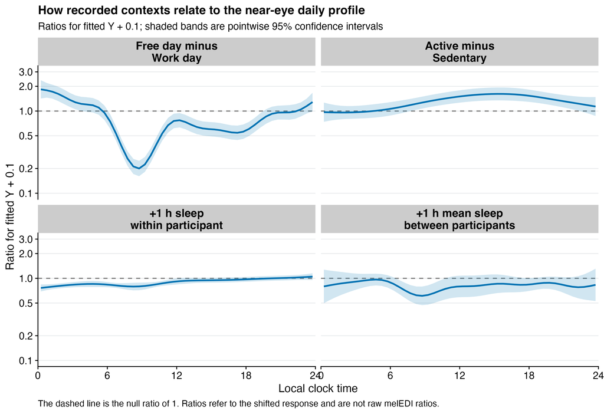

Figure 5: Time-varying near-eye context associations from the exploratory 30-minute GAMM. Curves are ratios for fitted Y plus 0.1 lx; bands are pointwise 95% confidence intervals.

Source data for the temporal GAMM figure

Table 12: Exploratory primary near-eye 30-minute GAMM summaries.

| Estimand | Ratio range over day | Strongest fitted association | Pointwise intervals excluding 1 | Whole-function FDR q |
| --- | --- | --- | --- | --- |
| Free day minus Work day | 0.20 to 1.84 | 08:45: 0.20 times | 35 / 48 | **<0.001** |
| Active minus Sedentary | 0.96 to 1.62 | 15:15: 1.62 times | 29 / 48 | **<0.001** |
| +1 h previous-night sleep within participant | 0.76 to 1.05 | 00:15: 0.76 times | 24 / 48 | **<0.001** |
| +1 h participant-mean previous-night sleep between participants | 0.61 to 0.97 | 08:45: 0.61 times | 9 / 48 | **<0.001** |

Ratios refer to fitted Y + 0.1 lx, not the raw-scale arithmetic mean Y. The q-values are approximate whole-function tests in one four-test FDR family. All displayed curve intervals are pointwise, not simultaneous.

All four whole-function tests met the exploratory FDR rule. The Free/Work ratio was lowest at 08:45, 0.20, but exceeded 1 after midnight, reaching 1.84. The Active/Sedentary ratio reached 1.62 at 15:15. One additional hour of sleep within participant was most strongly associated at 00:15, ratio 0.76. One additional hour of participant-mean sleep had its strongest fitted association at 08:45, ratio 0.61. These are time-varying observational associations on the shifted-response scale, not causal effects or raw melEDI ratios.

## Comparison with the selected main H06 analysis

The selected main H06 analysis and this complementary analysis do not estimate the same quantity. Main H06 gives each supported participant-hour one row and models the zero-aware geometric mean melEDI for that hour, with all three contexts in one model. H06_daily gives each admissible participant-day one row per metric. Its primary models are predictor-specific, while the exploratory joint column below uses a common 715-day frame and includes all three contexts. Where a global predictor-by-site interaction met its FDR rule, the table uses the **site-average full contrast from that interaction model**, with every site weighted equally, and gives the range of its nine full site-specific ratios. Otherwise it uses the additive model’s common contrast. The additive-family association q-value remains the prespecified association test, while the global interaction q-value determines which effect model is displayed.

Table 13: Selected main hourly H06 versus daily mean-melEDI associations.

| Context | Main hourly H06, jointly adjusted | Daily mean, predictor-specific | Daily mean, mutually adjusted exploratory |
| --- | --- | --- | --- |
| Work/free day | **Interaction model: site-average full contrast** 1.15 times (0.93 to 1.44) Full site-specific ratios: 0.53 to 2.44 Additive-family association q = 0.004; global site-interaction q = 0.017 | **Interaction model: site-average full contrast** 0.70 times (0.63 to 0.78) Full site-specific ratios: 0.40 to 0.95 Additive-family association q = <0.001; global site-interaction q = 0.002 | **Interaction model: site-average full contrast** 0.73 times (0.66 to 0.81) Full site-specific ratios: 0.44 to 1.00 Additive-family association q = <0.001; global site-interaction q = <0.001 |
| Daily activity status | **Additive model: common contrast** 2.06 times (1.54 to 2.76) Additive-family association q = <0.001; global site-interaction q = 0.644 | **Interaction model: site-average full contrast** 1.22 times (1.08 to 1.39) Full site-specific ratios: 0.84 to 2.26 Additive-family association q = 0.035; global site-interaction q = 0.014 | **Additive model: common contrast** 1.16 times (1.03 to 1.29) Additive-family association q = 0.027; global site-interaction q = 0.056 |
| Previous-night sleep duration | **Additive model: common contrast** 0.98 times (0.85 to 1.12) Additive-family association q = 0.745; global site-interaction q = 0.887 | **Additive model: common contrast** 0.89 times (0.86 to 0.92) Additive-family association q = <0.001; global site-interaction q = 0.140 | **Additive model: common contrast** 0.90 times (0.87 to 0.93) Additive-family association q = <0.001; global site-interaction q = 0.262 |

All entries are site-average ratios, with sites weighted equally, and pointwise 95% CIs, but their outcomes, weighting, fitted samples, model families, and multiplicity families differ. Supported interaction rows use the site-average geometric mean of the nine full site-specific ratios from that model and show the site range. Other rows use the additive common contrast. Interaction-model site ratios are full contrasts and require no multiplication by a main effect. Numerical equality is neither expected nor claimed.

The clearest contrast is day type, for which all three global site interactions were supported. The interaction-model site-average ratio was 1.15 (95% CI 0.93 to 1.44) in main hourly H06, with full site-specific ratios from 0.53 to 2.44. Daily mean melEDI was lower on Free days in both the predictor-specific interaction model, site-average ratio 0.70 (0.63 to 0.78; site range 0.40 to 0.95), and the mutually adjusted interaction model, 0.73 (0.66 to 0.81; site range 0.44 to 1.00). This is not a failed replication. The hourly analysis weights days by their supported hours and targets a retained hour’s geometric mean; the daily analysis weights admissible days equally and targets a daily metric.

Activity was positive in all three analyses. Its primary daily interaction was supported, so that column uses the interaction-model site-average ratio 1.22 (1.08 to 1.39; full site ratios 0.84 to 2.26). The main hourly and mutually adjusted daily activity interactions were not supported, so their displayed 2.06 and 1.16 ratios come from additive models. Previous sleep had no supported site interaction in any column. It was compatible with little hourly association, additive ratio 0.98 and FDR q = 0.745, but was associated with lower daily mean melEDI, additive ratios 0.89 and 0.90. The analyses therefore provide related but non-interchangeable evidence about hourly exposure and participant-day metrics.

## Model checks and limitations

### Primary and gap-sensitivity daily grid

All 468 non-L10 model cells passed the hard construct, support, numerical, and estimability gates, but every cell was classified **acceptable with limitations** after direct visual review of residual centering, variance, and gross distributional shape. No gross residual failure was observed.

Temporal dependence was retained as a mandatory model-check sidecar rather than an automatic failure criterion. Actual-date AR counterparts were sometimes singular, numerically unresolved, or left residual dependence; those findings remain part of interpretation but do not replace the primary estimates or p-values. In the primary timing route, the first-light Work/Free Student-t estimate shifted by 1.23 participant-cluster HC3 standard errors, and the L10 midpoint activity AR estimate shifted by 1.26 HC3 standard errors. Timing predictor-by-site results remain sensitivity-dependent.

Participant/site deletion checks were stable for 270 of 468 cells, showed a substantial limitation for 128, were unstable for 46, and had a non-estimable deletion refit for 24. Gaussian, Tweedie, Student-t, exact-period, and AR model-check sidecars are reported as response-family or stability limitations; none was used to substitute a p-value. MDER additionally retains its heavy-tail and site-influence qualifications.

Table 14: Model-check and sensitivity classifications.

| Classification | Cells | Role |
| --- | --- | --- |
| Overall H01-aligned cell status |  |  |
| Acceptable with limitations | 468 | Overall classification |
| Visual residual review |  |  |
| Review limitation | 468 | Overall classification |
| Participant/site deletion influence |  |  |
| Stable | 270 | Mandatory nonblocking limitation sidecar |
| Substantial limitation | 128 | Mandatory nonblocking limitation sidecar |
| Non-estimable deletion refit | 24 | Mandatory nonblocking limitation sidecar |
| Unstable | 46 | Mandatory nonblocking limitation sidecar |
| Gaussian Student-t sensitivity |  |  |
| Non-estimable sensitivity | 7 | Mandatory nonblocking limitation sidecar |
| Stable | 20 | Mandatory nonblocking limitation sidecar |
| Substantial limitation | 2 | Mandatory nonblocking limitation sidecar |
| Timing Student-t sensitivity |  |  |
| Stable | 135 | Mandatory nonblocking limitation sidecar |
| Substantial limitation | 8 | Mandatory nonblocking limitation sidecar |
| Unstable | 1 | Mandatory nonblocking limitation sidecar |
| Mixed-model actual-date AR sidecar |  |  |
| Acceptable | 3 | Mandatory nonblocking limitation sidecar |
| Acceptable pre-sleep no-nugget sensitivity | 1 | Mandatory nonblocking limitation sidecar |
| Not triggered | 119 | Mandatory nonblocking limitation sidecar |
| Triggered; no counterpart for the non-Gaussian route | 63 | Mandatory nonblocking limitation sidecar |
| Unresolved numerical failure | 13 | Mandatory nonblocking limitation sidecar |
| Unresolved singular fit | 104 | Mandatory nonblocking limitation sidecar |
| Residual dependence remained | 21 | Mandatory nonblocking limitation sidecar |
| Timing HC3 actual-date AR sidecar |  |  |
| Stable | 95 | Mandatory nonblocking limitation sidecar |
| Substantial limitation | 7 | Mandatory nonblocking limitation sidecar |
| Unresolved numerical failure | 32 | Mandatory nonblocking limitation sidecar |
| Unstable | 10 | Mandatory nonblocking limitation sidecar |
| Exact-period sensitivity |  |  |
| Stable | 12 | Mandatory nonblocking limitation sidecar |
| Substantial limitation | 6 | Mandatory nonblocking limitation sidecar |

Residual review and hard construct/support/numerical checks determine overall usability. AR, influence, family, and exact-period rows are mandatory nonblocking limitation sidecars under the analysis rule.

### Exploratory mutually adjusted daily models

All 14 estimable joint models and their required additive and one-interaction structures were numerically estimable. Direct residual-plot review classified all 14 as review limitations and none as a gross failure. First-light timing retained a U-shaped residual pattern and heavy tails under the participant-HC3 route. MDER retained pronounced upper-tail and site-influence limitations. Actual-date residual lag was reported descriptively and did not replace or invalidate an otherwise usable model. No deletion batch, bootstrap, or simulation was added to this exploratory analysis.

### Exploratory temporal GAMM

Five of six fitted frames met the accepted formula, convergence, basis, residual, temporal-dependence, fixed-term-identifiability, and cyclic-closure rules. All six BAM fits converged without fitting warnings, but the paired chest frame did not meet the residual-scale extraction rule and contributed no association summary. In the primary near-eye fit, the residual Q-Q correlation was 0.965, the absolute-residual/fitted Spearman correlation was 0.293, final pooled lag-1 correlation was 0.090, and the largest absolute site lag-1 correlation was 0.159. The bounded `k = 16` check supported retaining `k = 12`. Participant and site deletion robustness remains untested for the GAMM, so its results stay exploratory.

These are observational associations with recorded day-level contexts. They do not establish causal effects, health outcomes, identical associations across sites, or equivalence between sensor placements.

## Preregistration context and source data

The preregistration-deviations page records why the selected main H06 report uses the hourly estimand and this daily-metric report is complementary. The same page records the primary predictor scope, the model and site structure, and the multiplicity and contrast decisions.

Reader source data:

- complete primary results;
- complete complementary placement results;
- complete gap-timing-unaware results;
- primary site-specific interaction estimates;
- mutually adjusted common-sample stability results;
- mutually adjusted site estimates;
- main hourly H06 comparison;
- 30-minute temporal GAMM summary;
- 12-family primary and sensitivity summary; and
- model-check classification summary.